# Tema 7 - Contrastes de hipótesis paramétricos

## Nociones básicas

## Decisiones

Definición. Un *contraste de hipótesis* \[ \left\{\begin{array}{ll} H_{0}:\mbox{hipótesis nula}\\ H_{1}:\mbox{hipótesis alternativa} \end{array} \right. \] consiste en plantear dos hipótesis:

- *Hipótesis nula \(H_{0}\)*: es la hipótesis que “por defecto” aceptamos como verdadera, y que rechazamos si hay pruebas en contra,
- *Hipótesis alternativa \(H_{1}\)*: es la hipótesis contra la que contrastamos la hipótesis nula y que aceptamos cuando rechazamos la nula,

y generar una **regla de decisión** para **rechazar** o no la hipótesis nula a partir de la información contenida en una muestra.

## La similitud entre un juicio y un **contraste de hipótesis**

En un juicio, tenemos que declarar a un acusado inocente o culpable.

\[ \left\{\begin{array}{ll} H_{0}:\mbox{El acusado es inocente.}\\ H_{1}:\mbox{El acusado es culpable.} \end{array} \right. \]

Las pruebas serían los elementos de la muestra.

Si el jurado encuentra pruebas suficientemente incriminatorias, declara **culpable** al acusado (rechaza \(H_0\) en favor de \(H_1\)). En caso contrario, si no las encuentra suficientemente incriminatorias, le declara **no culpable** (no rechaza \(H_0\))

Considerar no culpable \(\neq\) declarar inocente.

## ¿Cómo escoger \(H_0\) y \(H_1\)?

Las pruebas tienen que aportar evidencia de \(H_1\), que nos permitirá rechazar \(H_0\).

Es imposible encontrar evidencias de que \(\mu\) sea igual a un cierto valor \(\mu_0\). En cambio, sí que es puede hallar evidencias de que \(\mu > \mu_0\) , o de que \(\mu<\mu_0\), o que \(\mu\neq\mu_0\).

En este contexto:

- \(H_1\) se define con \(>\), \(<\), o \(\neq\).
- \(H_0\) se define con \(=\), \(\leq\), o \(\geq\).
- \(H_1\) es la hipótesis de la que podemos hallar pruebas incriminatorias, \(H_0\) la que estamos dispuestos a aceptar si no hay pruebas en contra.

## Tipos de hipótesis alternativas

- **Hipótesis unilateral** (*one-sided*, también *de una cola*, *one-tailed*): \(H: \theta>\theta_{0}\), \(H: \theta<\theta_0\).
- **Hipótesis bilateral** (*two-sided*, también *de dos colas*, *two-tailed*): \(H: \theta\neq\theta_0\)

Los tests suelen tomar el nombre de la hipótesis alternativa: **test unilateral**, **test de dos colas**, etc.

## Tipos de errores

La tabla siguiente resume los 4 casos que se pueden dar dependiendo de la decisión tomada:

| Decisión/Realidad | \(H_{0}\) cierta | \(H_{0}\) falsa |
| --- | --- | --- |
| Aceptar \(H_{0}\) | Decisión correcta | Error Tipo II |
|  | Probabilidad=\(1-\alpha\) | Probabilidad=\(\beta\) |
| Rechazar \(H_{0}\) | Error Tipo I | Decisión correcta |
|  | Probabilidad=\(\alpha\) | Probabilidad=\(1-\beta\) |

## Tipos de errores

- **Error de Tipo I**: rechazar \(H_0\) cuando es cierta. La probabilidad de cometerlo es: \[P(\mbox{Error Tipo I})=P(\mbox{Rechazar } H_{0}\mid H_{0} \mbox{ cierta})=\alpha,\] donde \(\alpha\) es el **nivel de significación del contraste**.
- **Error de Tipo II**: aceptar \(H_0\) cuando es falsa. La probabilidad de cometerlo es: \[P(\mbox{Error Tipo II})=P(\mbox{Aceptar } H_{0}| H_{0} \mbox{ falsa})=\beta,\] donde \(1-\beta=P(\mbox{Rechazar } H_{0}|H_{0} \mbox{ falsa})\) es la **potencia del contraste**.

## Tipos de errores

Lo más conveniente es encontrar una regla de rechazo de \(H_{0}\) que tenga poca probabilidad de error de tipo I, \(\alpha\).

Pero también querríamos minimizar la probabilidad de error de tipo II, \(\beta\).

Observación: cuando hacemos disminuir \(\alpha\), suele aumentar \(\beta\).

**¿Qué se suele hacer?**

- Encontrar una regla de decisión para a un \(\alpha\) máximo fijado.
- Después, si es posible, controlar la tamaño \(n\) de la muestra para minimizar \(\beta\).

## Terminología

En un contraste de hipótesis, tenemos los siguientes conceptos:

- **Estadístico de contraste**: es una variable aleatoria función de la muestra que nos permite definir una regla de rechazo de \(H_{0}\).
- **Nivel de significación \(\alpha\)**: la probabilidad de error de tipo I.
- **Región crítica o de rechazo**: zona o región de números reales donde se verifica que si el **estadístico de contraste** pertenece a la **región crítica**, entonces rechazamos \(H_{0}\).
- **Región de aceptación**: zona o región complementaria de la **región crítica**.

## Terminología

- **Intervalo de confianza del \((1-\alpha)\cdot 100\%\)**: intervalo de confianza para el parámetro poblacional del contraste. Es equivalente afirmar que el estadístico de contraste pertenece a la **región de aceptación** que afirmar que el parámetro del contraste pertenece al **intervalo de confianza del contraste**.

## Contrastes de hipótesis para el parámetro \(\mu\) de una variable normal con \(\sigma\) conocida

## Contrastes de hipótesis para el parámetro \(\mu\) de una variable normal con \(\sigma\) conocida

Sea \(X\) una variable aleatoria \(N(\mu,\sigma)\) con \(\mu\) desconocida y \(\sigma\) conocida.

Sea \(X_{1},\ldots,X_{n}\) una m.a.s. de \(X\) de tamaño \(n\).

Nos planteamos el contraste siguiente: \[ \left\{\begin{array}{l} H_{0}:\mu=\mu_{0}\\ H_{1}:\mu >\mu_0 \end{array} \right. \] De cara a hallar la región de rechazo, pensemos que tenemos que rechazar \(H_0\) en favor de \(H_1\) si \(\overline{X}\) es “bastante más grande” que \(\mu_0\).

## Contrastes de hipótesis para el parámetro \(\mu\) de una variable normal con \(\sigma\) conocida

Si \(H_0\) es verdadera,

\[ Z=\frac{\overline{X}-\mu_{0}}{\frac{\sigma}{\sqrt{n}}}\sim N(0,1) \]

Entonces, la regla consistirá en rechazar \(H_{0}\) si el **estadístico de contraste** \(Z\) es mayor que un cierto umbral, que determinaremos con \(\alpha\), el **nivell de significación del contraste** o **el error tipo I**.

## Contrastes de hipótesis para el parámetro \(\mu\) de una variable normal con \(\sigma\) conocida

De cara a hallar la región de rechazo, queremos que se cumpla lo siguiente: \[ \begin{array}{l} \alpha =P(\mbox{rechazar } H_{0}| H_{0} \mbox{ cierta })=P(Z>\mbox{umbral })\\ \quad \Longrightarrow 1-\alpha= P(Z\leq \mbox{umbral })\Longrightarrow \mbox{umbral }=z_{1-\alpha}. \end{array} \] Por tanto, para que el **nivel de significación del contraste** sea \(\alpha\), la regla de rechazo tiene que ser: \(Z>z_{1-\alpha}\)

En resumen, **rechazamos \(H_0\)** si \(\dfrac{\overline{X}-\mu_{0}}{\sigma/\sqrt{n}}>z_{1-\alpha}\).

## Contrastes de hipótesis para el parámetro \(\mu\) de una variable normal con \(\sigma\) conocida

Gráfico de la región de rechazo. Las abscisas o coordenadas \(x\) de la zona en azul serían los valores \(z\) para los que rechazaríamos la hipótesis nula \(H_0\):

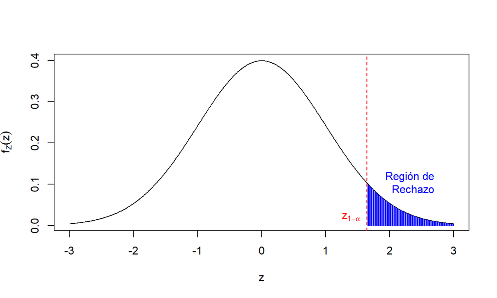

## Contrastes de hipótesis para el parámetro \(\mu\) de una variable normal con \(\sigma\) conocida

El contraste anterior tiene como:

- **Estadístico de contraste**: \(Z=\dfrac{\overline{X}-\mu_0}{\frac{\sigma}{\sqrt{n}}}\).
- **Región crítica**: \((z_{1-\alpha},\infty)\).
- **Región de aceptación**: \((-\infty,z_{1-\alpha}]\).
- **Regla de decisión**: rechazar \(H_0\) si \(Z>z_{1-\alpha}\).

## Contrastes de hipótesis para el parámetro \(\mu\) de una variable normal con \(\sigma\) conocida

- **Intervalo de confianza**: \[ \begin{array}{l} Z< z_{1-\alpha}\Longleftrightarrow \dfrac{\overline{X}-\mu_0}{\frac{\sigma}{\sqrt{n}}}< z_{1-\alpha} \Longleftrightarrow \mu_0> \overline{X}-z_{1-\alpha}\cdot\frac{\sigma}{\sqrt{n}}\\ \qquad\quad\Longleftrightarrow \mu_0\in {\Big(\overline{X}-z_{1-\alpha}\cdot\frac{\sigma}{\sqrt{n}},\infty\Big)} \end{array} \]
- **Regla de decisión II**: rechazar \(H_0\) si el \(\mu_0\) contrastado no pertenece al intervalo de confianza.

## Contraste de hipótesis para a \(\mu\) de normal con \(\sigma\) conocida

Sea \(X\) una v.a. \(N(\mu,\sigma)\) con \(\mu\) desconocida y \(\sigma\) conocida

Sea \(X_1,\ldots,X_{n}\) una m.a.s. de \(X\) de tamaño \(n\)

Nos planteamos el contraste \[ \left\{\begin{array}{l} H_0:\mu=\mu_0\\ H_1:\mu\ <\ \mu_0 \end{array} \right. \] donde vamos a rechazar \(H_0\) si \(Z=\dfrac{\overline{X}-\mu_0}{{\sigma}/{\sqrt{n}}}\) es *inferior a* un cierto umbral, que determinaremos con \(\alpha\).

## Contraste de hipótesis para una media poblacional \(\mu\) de una distribución normal con \(\sigma\) conocida

Queremos que el **Error Tipo I** sea \(\alpha\): \[ \alpha =P(\mbox{rechazar } H_0| H_0 \mbox{ cierta}) =P(Z<\mbox{umbral })\Longrightarrow \mbox{umbral }=z_{\alpha}, \] por lo tanto, para que el nivel de significación del contraste Sea \(\alpha\), la regla de rechazo tiene que ser \(Z<z_{\alpha}\).

La Región crítica es \((-\infty,z_{\alpha})\).

En resumen, **rechazamos \(H_0\)** si \(\dfrac{\overline{X}-\mu_{0}}{\sigma/\sqrt{n}} < z_{\alpha}=-z_{1-\alpha}\).

## Contrastes de hipótesis para el parámetro \(\mu\) de una variable normal con \(\sigma\) conocida

Gráfico de la región de rechazo. Las abscisas o coordenadas \(x\) de la zona en azul serían los valores \(z\) para los que rechazaríamos la hipótesis nula \(H_0\):

[figure not shown]

## Contrastes de hipótesis para el parámetro \(\mu\) de una variable normal con \(\sigma\) conocida

El contraste anterior tiene como:

- **Estadístico de contraste**: \(Z=\dfrac{\overline{X}-\mu_0}{\frac{\sigma}{\sqrt{n}}}\).
- **Región crítica**: \((-\infty,-z_{1-\alpha})\).
- **Región de aceptación**: \([-z_{1-\alpha},\infty)\).
- **Regla de decisión**: rechazar \(H_0\) si \(Z < -z_{1-\alpha}\).

## Contrastes de hipótesis para el parámetro \(\mu\) de una variable normal con \(\sigma\) conocida

- **Intervalo de confianza**: \[ \begin{array}{l} Z> -z_{1-\alpha}\Longleftrightarrow \dfrac{\overline{X}-\mu_0}{\frac{\sigma}{\sqrt{n}}}> -z_{1-\alpha} \Longleftrightarrow \mu_0< \overline{X}+z_{1-\alpha}\cdot\frac{\sigma}{\sqrt{n}}\\ \qquad\quad\Longleftrightarrow \mu_0\in {\Big(-\infty,\overline{X}+z_{1-\alpha}\cdot\frac{\sigma}{\sqrt{n}}\Big)} \end{array} \]
- **Regla de decisión II**: rechazar \(H_0\) si el \(\mu_0\) contrastado no pertenece al intervalo de confianza.

## Contraste de hipótesis para la media \(\mu\) de una población normal con \(\sigma\) conocida

Sea \(X\) una v.a. \(N(\mu,\sigma)\) con \(\mu\) desconocida y \(\sigma\) conocida

Sea \(X_1,\ldots,X_{n}\) una m.a.s. de \(X\) de tamaño \(n\)

Consideremos ahora el contraste \[ \left\{\begin{array}{l} H_0:\mu=\mu_0\\ H_1:\mu\ \neq\ \mu_0 \end{array} \right. \]

Rechazar \(H_0\) si \(Z=\dfrac{\overline{X}-\mu_0}{{\sigma}/{\sqrt{n}}}\) está a *bastante lejos de* de 0, y la determinaremos con el valor de \(\alpha\)

## Contraste de hipótesis para la media \(\mu\) de una población normal con \(\sigma\) conocida

Queremos como antes que el **Error Tipo I** sea \(\alpha\): \[ \begin{array}{rl} \alpha & =P(\mbox{rechazar } H_0| H_0 \mbox{ cierta }) =P(Z<-\mbox{umbral }\mbox{ o }Z>\mbox{umbral })\\ & =P(Z<-\mbox{umbral })\!+\!P(Z>\mbox{umbral }) = 2P(Z>\mbox{umbral }) \\ &= 2(1-P(Z<\mbox{umbral })) \Longrightarrow P(Z<\mbox{umbral })=1-\dfrac{\alpha}2,\\ & \qquad \Longrightarrow \mbox{umbral }=z_{1-\frac{\alpha}2}. \end{array} \]

## Contraste de hipótesis para la media \(\mu\) de una población normal con \(\sigma\) conocida

Ahora para que el nivel de significación del contraste sea \(\alpha\), la **regla de rechazo** tiene que ser \[ Z<-z_{1-\frac{\alpha}2}=z_{\frac{\alpha}2}\mbox{ o }Z>z_{1-\frac{\alpha}2}. \] La región crítica es \((-\infty,z_{\frac\alpha2})\cup (z_{1-\frac{\alpha}2},\infty).\)

## Contraste de hipótesis para la media \(\mu\) de una población normal con \(\sigma\) conocida

Gráfico de la región de rechazo. Las abscisas o coordenadas \(x\) de la zona en azul serían los valores \(z\) para los que rechazaríamos la hipótesis nula \(H_0\):

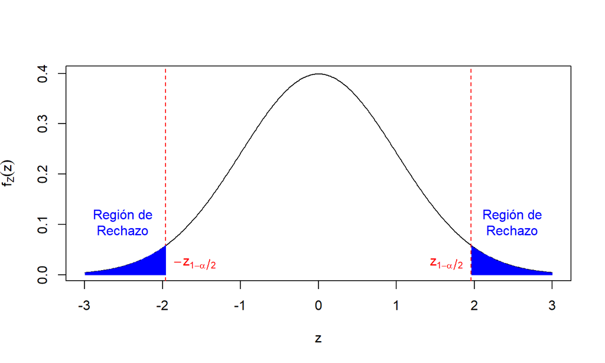

## Contraste de hipótesis para la media \(\mu\) de una población normal con \(\sigma\) conocida

Seguidamente, calculemos el **Intervalo de confianza** para el contraste anterior: \[ \begin{array}{l} -z_{1-\frac{\alpha}2} < Z < z_{1-\frac{\alpha}2}\Longleftrightarrow -z_{1-\frac{\alpha}2} < \dfrac{\overline{X}-\mu_0}{\frac{\sigma}{\sqrt{n}}}< z_{1-\frac{\alpha}2}\\ \qquad\Longleftrightarrow -z_{1-\frac{\alpha}2}\frac{\sigma}{\sqrt{n}}< \overline{X}-\mu_0< z_{1-\frac{\alpha}2}\frac{\sigma}{\sqrt{n}}\\\qquad \Longleftrightarrow \overline{X}-z_{1-\frac\alpha2}\frac{\sigma}{\sqrt{n}}< \mu_0< \overline{X}+z_{1-\frac{\alpha}2}\frac{\sigma}{\sqrt{n}} \\ \qquad\Longleftrightarrow\mu_0\in \Big(\overline{X}-z_{1-\frac\alpha2}\frac{\sigma}{\sqrt{n}},\overline{X}+z_{1-\frac{\alpha}2}\frac{\sigma}{\sqrt{n}}\Big) \end{array} \]

## El \(p\)-valor

El *\(p\)-valor* o *valor crítico* (\(p\)-*value*) de un contraste es la probabilidad que, si \(H_0\) es verdadera, el estadístico de contraste tome un valor tan extremo o más que el que se ha observado.

Consideremos por ejemplo un contraste del tipo: \[ \left\{\begin{array}{l} H_0:\mu=\mu_0\\ H_1:\mu\ >\ \mu_0. \end{array} \right. \] Si el estadístico \(Z\) tiene el valor \(z_0\), el \(p\)-valor será: \[ \mbox{$p$-valor}=P(Z\ \geq\ z_0). \]

## El \(p\)-valor

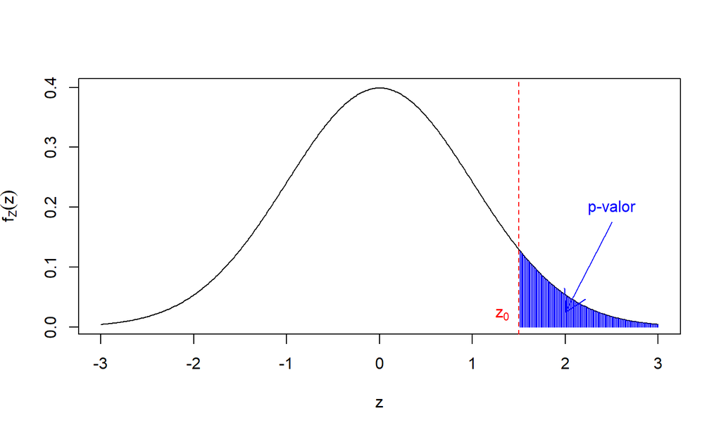

## El \(p\)-valor

Para el contraste:

\[ \left\{\begin{array}{l} H_0:\mu=\mu_0\\ H_1:\mu\ <\ \mu_0. \end{array} \right. \] Si el estadístico \(Z\) tiene el valor \(z_0\), el \(p\)-valor será: \[ \mbox{$p$-valor}=P(Z\ \leq\ z_0). \]

## El \(p\)-valor

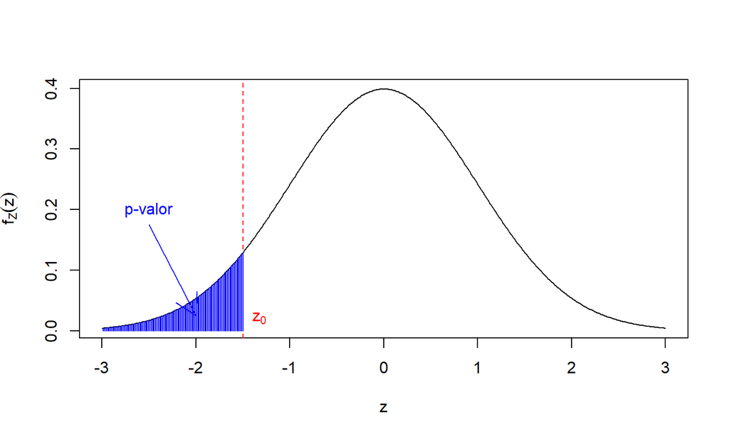

## El \(p\)-valor

Si ahora consideramos el contraste \[ \left\{\begin{array}{l} H_0:\mu=\mu_0\\ H_1:\mu\ \neq\ \mu_0 \end{array} \right. \] y si el estadístico \(Z\) ha dado \(z_0\), el \(p\)-valor será: \[ \mbox{$p$-valor} =2 \cdot \min\{P(Z \leq -|z_0|),P(Z \geq |z_0|) =2\cdot P(Z \geq |z_0|) \]

## El \(p\)-valor

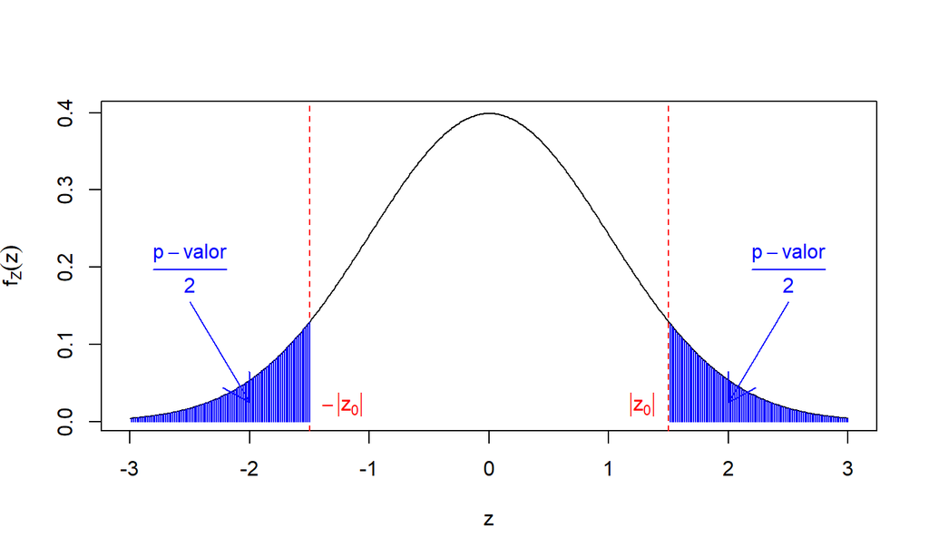

## El \(p\)-valor

El *\(p\)-valor* o *valor crítico* (\(p\)-*value*) de un contraste es la probabilidad que, si \(H_0\) es verdadera, el estadístico de contraste tome un valor tan extremo o más que el que se ha observado.

En consecuencia, cuanto más pequeño sea el \(p\)-valor, con más fuerza podemos rechazar \(H_0\).

## El \(p\)-valor

Supongamos, por ejemplo, que hemos obtenido un \(p\)-valor de \(0.03\):

- *Significa* que la probabilidad de que, si \(H_0\) es verdadera, el estadístico de contraste tome un valor tan extremo o más que el que ha tomado, es 0.03 (**pequeño: evidencia de que \(H_0\) es falsa.**)
- *No significa*:
  - La probabilidad que \(H_0\) Sea verdadera es \(0.03\)
  - \(H_0\) es verdadera un 3% de les veces

## El \(p\)-valor

Importante:

En un contraste con nivel de significación \(\alpha\),

- rechazamos \(H_0\) si \(p\)-valor \(<\alpha\).
- aceptamos \(H_0\) si \(\alpha\leq p\)-valor.

## El \(p\)-valor

Si consideramos por ejemplo un contraste del tipo: \[ \left\{\begin{array}{l} H_0:\mu=\mu_0\\ H_1:\mu> \mu_0 \end{array} \right. \]

y suponemos que el estadístico \(Z\) vale \(z_0\). El \(p\)-valor es \(P(Z \geq z_0)\). Entonces:

- Rechazamos \(H_0\) \(\Longleftrightarrow z_0>z_{1-\alpha},\),
- O, dicho de otra forma, \[\mbox{$p$-valor}=P(Z \geq z_0)<P(Z\geq z_{1-\alpha})=1-(1-\alpha)=\alpha.\]

## El \(p\)-valor

Si ahora consideramos un contraste del tipo: \[ \left\{\begin{array}{l} H_0:\mu=\mu_0\\ H_1:\mu < \mu_0 \end{array} \right. \]

y suponemos que el estadístico \(Z\) vale \(z_0\). El \(p\)-valor es \(P(Z \leq z_0)\). Entonces:

- Rechazamos \(H_0\) \(\Longleftrightarrow z_0 < z_{\alpha},\)
- O, dicho de otra forma, \[\mbox{$p$-valor}=P(Z \leq z_0) < P(Z\leq z_{\alpha})=\alpha.\]

## El \(p\)-valor

Por último, supongamos que el contraste es del tipo: \[ \left\{\begin{array}{l} H_0:\mu=\mu_0\\ H_1:\mu \neq \mu_0 \end{array} \right. \] y que el estadístico \(Z\) vale \(z_0>0\). El \(p\)-valor es \(2P(Z \geq |z_0|)\). Entonces:

- Rechazamos \(H_0 \Longleftrightarrow |z_0|>z_{1-\frac{\alpha}{2}}\),
- O, dicho de otra forma, \[ \mbox{$p$-valor}=2P(Z \geq |z_0|)<2P(Z\geq z_{1-\frac{\alpha}2})=2\left(1-\left(1-\frac{\alpha}2\right)\right)=\alpha. \]

## El \(p\)-valor

El *\(p\)-valor* de un contraste es:

- El nivel de significación \(\alpha\) más pequeño para el que rechazamos la hipótesis nula.
- El nivel de significación \(\alpha\) más grande para el que aceptaríamos la hipótesis nula.
- La probabilidad mínima de error de Tipo I que permitimos si rechazamos la hipótesis nula con el valor del estadístico de contraste obtenido.
- La probabilidad máxima de error de Tipo I que permitimos si aceptamos la hipótesis nula con el valor del estadístico de contraste obtenido.

## El \(p\)-valor

Importante:

Si no establecemos un nivel de significación \(\alpha\), entonces

- Aceptamos \(H_0\) si el \(p\)-valor es “grande” (\(\geq 0.1\)).
- Rechazamos \(H_0\) si el \(p\)-valor es “pequeño” (\(<0.05\)). En este caso, el \(p\)-valor es:
  - *Significativo* si es \(< 0.05\) (En `R`, se simboliza con un asterisco, `*`).
  - *Fuertemente significativo* si es \(<0.01\) (En `R`, se simboliza con dos asteriscos, `**`).
  - *Muy significativo* si es \(<0.001\) (En `R`, se simboliza con tres asteriscos, `***`).

## El \(p\)-valor

Si el \(p\)-valor está entre \(0.05\) y \(0.1\) y no tenemos nivel de significación, se requieren estudios posteriores para tomar una decisión.

Es la denominada **zona crepuscular**, o *twilight zone*.

## El método de los *seis* pasos (caso de conocer \(\alpha\))

1. Establecer la hipótesis nula \(H_0\) y la hipótesis alternativa \(H_1\).
2. Fijar un nivel de significación \(\alpha\).
3. Seleccionar el estadístico de contraste apropiado.
4. Calcular el valor del estadístico de contraste a partir de les datos muestrales.
5. Calcular el \(p\)-valor del contraste.
6. **Decisión:** rechazar \(H_0\) en favor de \(H_1\) si el \(p\)-valor es más pequeño que \(\alpha\); en caso contrario, aceptar \(H_0\).

## El método de los *cinco* pasos (caso de no conocer \(\alpha\))

1. Establecer la hipótesis nula \(H_0\) y la hipótesis alternativa \(H_1\).
2. Seleccionar el estadístico de contraste apropiado.
3. Calcular el valor del estadístico de contraste a partir de los valores de la muestra.
4. Calcular el \(p\)-valor del contraste.
5. **Decisión:** rechazar \(H_0\) en favor de \(H_1\) si el \(p\)-valor es pequeño (\(<0.05\)), aceptar \(H_0\) si el \(p\)-valor es grande (\(\geq 0.1\)), y ampliar el estudio si el \(p\)-valor está entre 0.05 y 0.1.